# Comparing missing-data estimates across three ZEAL datasets

- Show All Code
- Hide All Code
- View Source

Missing-data modelling in ZEAL, part 3 of 3 — fitting the floor model to WGS, Wideseq, and SNP50K

Author

Fausto Rodríguez-Zapata

Published

July 16, 2026

**Purpose.** Take the exponential-with-floor model developed in `missing-data-floor-model.qmd` and evaluate how stable its parameters ($\pi$, $k$) are when the *same* ZEAL samples are viewed through three different data products: whole-genome `picard` WGS metrics, the 27 M-SNP Wideseq binned counts, and a filtered 50 K SNP panel.

**NoteWhere this sits in the series**

1. `missing-data-coverage-theory.qmd` — Poisson coverage theory (the baseline).
2. `missing-data-floor-model.qmd` — the exponential-with-floor model, fit to ZEAL BAM alignments.
3. **This note** — the floor model applied to, and compared across, three ZEAL datasets.

```r
suppressMessages({
  library(here)
  library(readr)
  library(dplyr)
  library(tidyr)
  library(ggplot2)
  library(ggpubr)
  library(cowplot)
  library(minpack.lm)
  library(viridis)
  library(knitr)
})
```

## Helper functions

These wrap the per-dataset workflow from part 2 so the same fit and plots apply to every dataset. They live in `R/missing_data_models.R` (ported verbatim from the original `modeling_functions.R`) and are sourced here, so the fit and the figure share one canonical definition and cannot drift from a retyped copy.

```r
source(here("R/missing_data_models.R"))
```

# 1 Data loading and processing

We load and process three datasets. Each needs a slightly different route to the same two metrics: mean coverage (`lambda`) and observed missingness (`missing_obs`).

## 1.1 Dataset 1: WGS metrics summary

Derived from `WGSmetrics_summary.tsv` (`picard CollectWgsMetrics` output), reduced to a per-sample summary by `scripts/make_missing_data_summaries.R`:

$\lambda = \texttt{MEAN\_COVERAGE}$, $\texttt{missing\_obs} = 1 - \texttt{PCT\_1X}$.

```r
per_sample_wgs <- read_tsv(
  here("data/missing_data/wgs_per_sample.tsv"),
  show_col_types = FALSE
) %>%
  filter(is.finite(lambda) & is.finite(missing_obs))

head(per_sample_wgs)
```

```
# A tibble: 6 × 3
  SAMPLE      lambda missing_obs
  <chr>        <dbl>       <dbl>
1 PN10_SID865  0.262       0.806
2 PN10_SID866  0.907       0.558
3 PN10_SID867  0.534       0.680
4 PN10_SID868  0.608       0.651
5 PN10_SID869  0.545       0.683
6 PN10_SID870  0.637       0.640
```

## 1.2 Dataset 2: ZEAL Wideseq (27 M binned genotypes)

Derived from `all_samples_bin_genotypes.tsv` — the same source used in part 2, via the shared per-sample summary from `scripts/make_missing_data_summaries.R`.

```r
per_sample_bzea <- read_tsv(
  here("data/missing_data/wideseq_per_sample.tsv"),
  show_col_types = FALSE
) %>%
  select(SAMPLE, lambda, missing_obs) %>%
  filter(is.finite(lambda) & is.finite(missing_obs))

head(per_sample_bzea)
```

```
# A tibble: 6 × 3
  SAMPLE      lambda missing_obs
  <chr>        <dbl>       <dbl>
1 PN10_SID865  0.415       0.739
2 PN10_SID866  1.40        0.446
3 PN10_SID867  0.867       0.573
4 PN10_SID868  0.945       0.550
5 PN10_SID869  0.888       0.575
6 PN10_SID870  0.998       0.534
```

## 1.3 Dataset 3: 50 K filtered SNPs

Derived from `allelic_counts50K.tsv` (per-site REF/ALT read counts), reduced to a per-sample summary by `scripts/make_missing_data_summaries.R`.

```r
per_sample_snp50K <- read_tsv(
  here("data/missing_data/snp50k_per_sample.tsv"),
  show_col_types = FALSE
) %>%
  select(SAMPLE, lambda, missing_obs) %>%
  filter(is.finite(lambda) & is.finite(missing_obs))

head(per_sample_snp50K)
```

```
# A tibble: 6 × 3
  SAMPLE      lambda missing_obs
  <chr>        <dbl>       <dbl>
1 PN10_SID865  0.313       0.769
2 PN10_SID866  0.961       0.466
3 PN10_SID867  0.666       0.586
4 PN10_SID868  0.676       0.579
5 PN10_SID869  0.697       0.579
6 PN10_SID870  0.724       0.558
```

# 2 Model fitting

Apply `fit_exp_floor_model()` to all three processed datasets.

```r
wgs_model_results <- fit_exp_floor_model(per_sample_wgs)
bzea_model_results <- fit_exp_floor_model(per_sample_bzea)
snp50K_model_results <- fit_exp_floor_model(per_sample_snp50K)

cat("WGS Metrics Model Parameters:\n")
```

```
WGS Metrics Model Parameters:
```

```r
cat("Floor (pi):", round(wgs_model_results$params$pi, 3), "\n")
```

```
Floor (pi): 0.446
```

```r
cat("Decay (k):", round(wgs_model_results$params$k, 3), "\n\n")
```

```
Decay (k): 1.661
```

```r
cat("ZEAL Binned Model Parameters:\n")
```

```
ZEAL Binned Model Parameters:
```

```r
cat("Floor (pi):", round(bzea_model_results$params$pi, 3), "\n")
```

```
Floor (pi): 0.346
```

```r
cat("Decay (k):", round(bzea_model_results$params$k, 3), "\n\n")
```

```
Decay (k): 1.256
```

```r
cat("SNP50K Model Parameters:\n")
```

```
SNP50K Model Parameters:
```

```r
cat("Floor (pi):", round(snp50K_model_results$params$pi, 3), "\n")
```

```
Floor (pi): 0.161
```

```r
cat("Decay (k):", round(snp50K_model_results$params$k, 3), "\n")
```

```
Decay (k): 1.042
```

# 3 Visual comparison of model fits

Generate the validation plots for all three models and display them side-by-side.

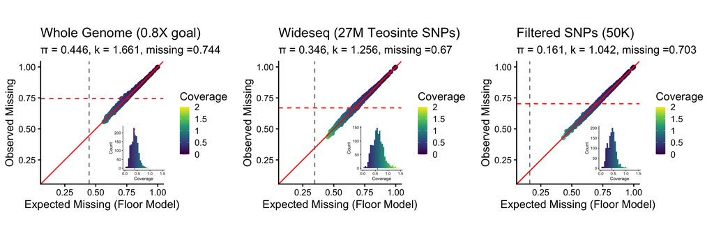

```r
hist_wgs <- generate_coverage_histogram(wgs_model_results$data)
hist_bzea <- generate_coverage_histogram(bzea_model_results$data)
hist_snp50K <- generate_coverage_histogram(snp50K_model_results$data)

plot_wgs <- generate_floor_model_plot(
  model_results = wgs_model_results,
  coverage_hist_plot = hist_wgs,
  plot_title = "Whole Genome (0.8X goal)"
)

plot_bzea <- generate_floor_model_plot(
  model_results = bzea_model_results,
  coverage_hist_plot = hist_bzea,
  plot_title = "Wideseq (27M Teosinte SNPs)"
)

plot_snp50K <- generate_floor_model_plot(
  model_results = snp50K_model_results,
  coverage_hist_plot = hist_snp50K,
  plot_title = "Filtered SNPs (50K)"
)

combined_plot <- plot_grid(plot_wgs, plot_bzea, plot_snp50K, ncol = 3)
print(combined_plot)
```

# 4 Summary statistics comparison

```r
summary_stats <- data.frame(
  Dataset = c("WGS", "Wideseq", "SNP50K"),
  Samples = c(
    nrow(per_sample_wgs), nrow(per_sample_bzea),
    nrow(per_sample_snp50K)
  ),
  Mean_Coverage = c(
    round(mean(per_sample_wgs$lambda), 2),
    round(mean(per_sample_bzea$lambda), 2),
    round(mean(per_sample_snp50K$lambda), 2)
  ),
  Mean_Missingness = c(
    round(mean(per_sample_wgs$missing_obs), 3),
    round(mean(per_sample_bzea$missing_obs), 3),
    round(mean(per_sample_snp50K$missing_obs), 3)
  ),
  Floor_Pi = c(
    round(wgs_model_results$params$pi, 3),
    round(bzea_model_results$params$pi, 3),
    round(snp50K_model_results$params$pi, 3)
  ),
  Decay_k = c(
    round(wgs_model_results$params$k, 3),
    round(bzea_model_results$params$k, 3),
    round(snp50K_model_results$params$k, 3)
  )
)

knitr::kable(
  summary_stats,
  caption = "Comparison of Model Parameters Across Datasets",
  col.names = c(
    "Dataset", "N Samples", "Mean Coverage", "Mean Missingness",
    "Floor (pi)", "Decay (k)"
  )
)
```

Comparison of Model Parameters Across Datasets

| Dataset | N Samples | Mean Coverage | Mean Missingness | Floor (pi) | Decay (k) |
| --- | --- | --- | --- | --- | --- |
| WGS | 1437 | 0.39 | 0.744 | 0.446 | 1.661 |
| Wideseq | 1434 | 0.59 | 0.670 | 0.346 | 1.256 |
| SNP50K | 1439 | 0.43 | 0.703 | 0.161 | 1.042 |

# 5 Interpretation

The floor $\pi$ moves in the expected direction with SNP ascertainment: the unfiltered whole-genome view carries the highest irreducible missingness ($\pi = 0.446$), the 27 M teosinte-variant Wideseq panel sits in the middle ($\pi = 0.346$), and the curated 50 K SNP panel — chosen to be well-behaved and mappable — has the lowest floor ($\pi = 0.161$). Filtering to informative, mappable sites removes much of the irreducible missingness, exactly as the mechanistic interpretation of $\pi$ (repetitive/structural/unmappable sequence) predicts. The decay rate $k$ likewise decreases toward 1 (the Poisson value) as the panel is cleaned, consistent with the filtered data behaving more like the idealized random-sampling baseline from `missing-data-coverage-theory.qmd`.